# Intermediate SQL Workflow

1. Introduction
2. Step 1: Setting Up the Environment
3. Step 2: Creating the Database
4. Step 3: Inserting Sample Data
5. Step 4: Running SQL Queries
6. Step 5: Intermediate SQL Queries
7. Step 6: Data Visualization
8. Step 7: Closing the Connection
9. Summary of Concepts Demonstrated

[figure not shown]

# Introduction

### SQL Portfolio Project: Analyzing a Sales Database Using Jupyter Notebook

> - This project will showcase my SQL skills at an intermediate level using SQLite in a Jupyter Notebook environment. I'll create a sales database, import data, and perform various SQL queries, demonstrating an ability to manipulate and analyze data.

# Step 1: Setting Up the Environment

### Importing required libraries

```python
import sqlite3
import pandas as pd
```

# Step 2: Creating the Database

### Create a connection to an SQLite database. This database will store our sales data.

```python
# Connecting to SQLite database (creates a new database file if not exists)
conn = sqlite3.connect("sales_data.db")
cursor = conn.cursor()
```

### I'll create two tables

1. `customers`: Stores customer details
2. `sales`: Stores sales transactions

```python
# Creating Customers table
cursor.execute('''
    CREATE TABLE IF NOT EXISTS customers (
        customer_id INTEGER PRIMARY KEY,
        name TEXT NOT NULL,
        city TEXT,
        state TEXT
    )
''')

# Creating Sales table
cursor.execute('''
    CREATE TABLE IF NOT EXISTS sales (
        sale_id INTEGER PRIMARY KEY,
        customer_id INTEGER,
        product TEXT,
        quantity INTEGER,
        price REAL,
        sale_date DATE,
        FOREIGN KEY (customer_id) REFERENCES customers(customer_id)
    )
''')

# Committing changes
conn.commit()
```

# Step 3: Inserting Sample Data

### I'll populate our tables with some data.

```python
# Inserting data into Customers table
customers_data = [
    (1, 'Alice Johnson', 'New York', 'NY'),
    (2, 'Bob Smith', 'Los Angeles', 'CA'),
    (3, 'Charlie Brown', 'Chicago', 'IL'),
    (4, 'David White', 'Houston', 'TX')
]

cursor.executemany("INSERT INTO customers VALUES (?, ?, ?, ?)", customers_data)

# Inserting data into Sales table
sales_data = [
    (1, 1, 'Laptop', 1, 1200.00, '2024-02-01'),
    (2, 2, 'Smartphone', 2, 800.00, '2024-02-05'),
    (3, 3, 'Tablet', 1, 400.00, '2024-02-10'),
    (4, 4, 'Monitor', 3, 300.00, '2024-02-12'),
    (5, 1, 'Keyboard', 2, 50.00, '2024-02-15')
]

cursor.executemany("INSERT INTO sales VALUES (?, ?, ?, ?, ?, ?)", sales_data)

# Committing changes
conn.commit()
```

# Step 4: Running SQL Queries

### Fetching all data

> - I'll now retrieve and display all customer records.

```python
df_customers = pd.read_sql_query("SELECT * FROM customers", conn)
df_customers
```

|  | customer_id | name | city | state |
| --- | --- | --- | --- | --- |
| 0 | 1 | Alice Johnson | New York | NY |
| 1 | 2 | Bob Smith | Los Angeles | CA |
| 2 | 3 | Charlie Brown | Chicago | IL |
| 3 | 4 | David White | Houston | TX |

Retrieving and displaying all sales transactions.

```python
df_sales = pd.read_sql_query("SELECT * FROM sales", conn)
df_sales
```

|  | sale_id | customer_id | product | quantity | price | sale_date |
| --- | --- | --- | --- | --- | --- | --- |
| 0 | 1 | 1 | Laptop | 1 | 1200.0 | 2024-02-01 |
| 1 | 2 | 2 | Smartphone | 2 | 800.0 | 2024-02-05 |
| 2 | 3 | 3 | Tablet | 1 | 400.0 | 2024-02-10 |
| 3 | 4 | 4 | Monitor | 3 | 300.0 | 2024-02-12 |
| 4 | 5 | 1 | Keyboard | 2 | 50.0 | 2024-02-15 |

# Step 5: Intermediate SQL Queries

### Joining tables

> - I'll fetch all sales along with customer names.

```python
query = '''
    SELECT sales.sale_id, customers.name, sales.product, sales.quantity, sales.price, sales.sale_date
    FROM sales
    JOIN customers ON sales.customer_id = customers.customer_id
'''
df_joined = pd.read_sql_query(query, conn)
df_joined
```

|  | sale_id | name | product | quantity | price | sale_date |
| --- | --- | --- | --- | --- | --- | --- |
| 0 | 1 | Alice Johnson | Laptop | 1 | 1200.0 | 2024-02-01 |
| 1 | 2 | Bob Smith | Smartphone | 2 | 800.0 | 2024-02-05 |
| 2 | 3 | Charlie Brown | Tablet | 1 | 400.0 | 2024-02-10 |
| 3 | 4 | David White | Monitor | 3 | 300.0 | 2024-02-12 |
| 4 | 5 | Alice Johnson | Keyboard | 2 | 50.0 | 2024-02-15 |

### Aggregating the data

> - Finding the total revenue generated from sales.

```python
query = "SELECT SUM(quantity * price) AS total_revenue FROM sales"
df_revenue = pd.read_sql_query(query, conn)
df_revenue
```

|  | total_revenue |
| --- | --- |
| 0 | 4200.0 |

### Sales by customer

> - Finding total sales value for each customer.

```python
query = '''
    SELECT customers.name, SUM(sales.quantity * sales.price) AS total_spent
    FROM sales
    JOIN customers ON sales.customer_id = customers.customer_id
    GROUP BY customers.name
    ORDER BY total_spent DESC
'''
df_sales_by_customer = pd.read_sql_query(query, conn)
df_sales_by_customer
```

|  | name | total_spent |
| --- | --- | --- |
| 0 | Bob Smith | 1600.0 |
| 1 | Alice Johnson | 1300.0 |
| 2 | David White | 900.0 |
| 3 | Charlie Brown | 400.0 |

### Finding the best-selling product

```python
query = '''
    SELECT product, SUM(quantity) AS total_sold
    FROM sales
    GROUP BY product
    ORDER BY total_sold DESC
    LIMIT 1
'''
df_best_product = pd.read_sql_query(query, conn)
df_best_product
```

|  | product | total_sold |
| --- | --- | --- |
| 0 | Monitor | 3 |

# Step 6: Data Visualization

### I'll visualize some of the results using matplotlib.

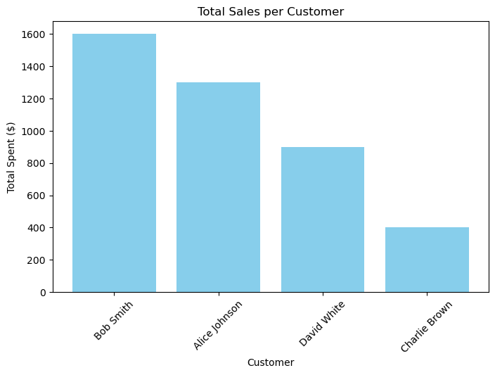

```python
import matplotlib.pyplot as plt

# Plot sales by customer
plt.figure(figsize=(8, 5))
plt.bar(df_sales_by_customer['name'], df_sales_by_customer['total_spent'], color='skyblue')
plt.xlabel('Customer')
plt.ylabel('Total Spent ($)')
plt.title('Total Sales per Customer')
plt.xticks(rotation=45)
plt.show()
```

# Step 7: Closing the Connection

After running all queries, I'll now close the connection.

```python
conn.close()
```

# Summary of Concepts Demonstrated

> - **`Database Creation`** – I created a database and tables
> - **`Data Insertion`** – I inserted records into tables
> - **`Basic Queries`** – I retrieved all data using SELECT
> - **`JOIN Operations`** – I combined tables using INNER JOIN
> - **`Aggregations`** – I calculated revenue and best-selling product using SUM()
> - **`Grouping & Ordering`** – I ranked customers by sales
> - **`Visualization`** – I displayed sales data using a bar chart